# Company Data Structure

Company Data Structure

## 1. internal corporate information system

- 데이터 계측 구조에서 실제 작동이 되는 use case 실물을 보여주는 것이 중요
- data - ai 기반 분석/통제 - 자동화 : 물류, 제작, 품질, 분류, 이동, 저장
- 기업 데이터들의 계층 구조

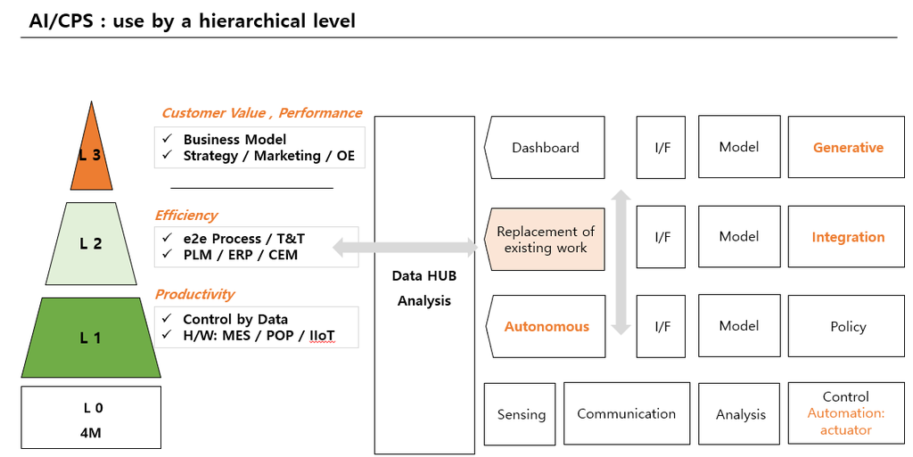

## 2. e2e Process

- 핵심 프로세스 중에서 ai 적용이 시급한 과제 도출
- Reading STEP files using python and giving them as input to a neural network
- Approaching STEP file analysis as a language processing task: A robust and scale-invariant solution for machining feature recognition

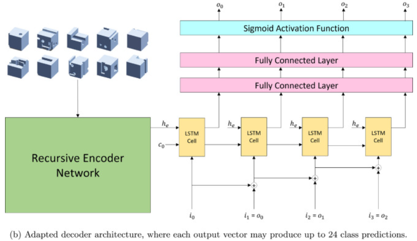

- 핵심 프로세스
- Order 2 Cash :
- source : https://www.aaravsolutions.com/realize-the-value-of-order-to-cash-process-a-detailed-outlook/

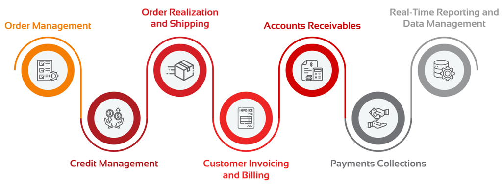

- Purchase to Pay (P2P)
- Idea to Product (I2P)
- Lead to Customer (L2C)
- settlement
- Order to Cash (O2C) Process:

Order Entry: Receiving and recording customer orders.  
Order Processing: Verifying product availability and processing the order.  
Picking and Packing: Retrieving items from inventory and preparing them for shipment.  
Shipping: Sending the products to customers.  
Invoicing: Generating invoices for the delivered products or services.  
Payment: Receiving and processing payments from customers.

- Purchase to Pay (P2P) Process:

Requisition: Identifying the need for goods or services and creating a requisition.  
Approval: Seeking approvals for the requisition based on organizational policies.  
Purchase Order (PO) Creation: Converting approved requisitions into purchase orders.  
Goods/Service Receipt: Receiving and verifying the goods or services against the purchase order.  
Invoice Matching: Matching supplier invoices with corresponding purchase orders and receipts.  
Payment: Processing payments to suppliers based on verified invoices.

- Idea to Product (I2P) Process:

Idea Generation: Coming up with product or service ideas.  
Planning and Design: Planning the details and designing the product or service.  
Development: Creating the product or service based on the plan.  
Testing: Conducting tests to ensure quality and functionality.  
Productization: Launching the product or service to the market.

- Lead to Customer (L2C) Process:

Lead Generation: Generating potential customer leads.  
Contact and Relationship Building: Establishing contact and building relationships with leads.  
Quoting and Proposing: Providing quotes or proposals for products or services.  
Contract and Closure: Finalizing contracts and closing deals.  
Implementation and Maintenance: Delivering products or services and providing ongoing maintenance.

- Hire to Retire (H2R) Process:

Recruitment: Attracting and hiring qualified employees.  
Onboarding: Integrating new employees into the organization.  
Performance Management: Evaluating and managing employee performance.  
Training and Development: Providing ongoing training and development opportunities.  
Retirement or Resignation: Managing employee exits from the organization.

- Project Lifecycle (PLC) Process:

Initiation: Defining the project’s scope, objectives, and stakeholders.  
Planning: Developing a detailed project plan, including resources and timelines.  
Execution: Implementing the project plan and carrying out project activities.  
Monitoring and Controlling: Tracking project progress, identifying issues, and making adjustments.  
Closure: Closing out the project, documenting lessons learned, and obtaining client acceptance.

## 3. ai 사용이 필요한 업무

- 4M 영역 : Sensing - Monitoring/Control - Actuator ; automation

### 예시

- 설계에서 CAD 모델링 후 PLM을 통하여 모든 데이터를 관리할 때 반복적이며 시간이 소요되는 업무
- 부품 설계 후 Item code 생성 및 BOM 작성 업무
- 참고

[figure not shown]

## 4. 기업이 주저하는 이유

1. one-stop service가 되지 않고 : 부분 부분 솔루션을 제시함
2. 시도하기 앞서 성공에 대한 확신이 없음
   - 개념만 얘기하고
   - 솔루션만 설명
   - 그같은 방법이 해당 기업에서 작동될 지를 스스로 확신하지 못함
3. 막상 하려고 하면 많은 자원을 필요로 하며 결과를 하기까지 긴 시간이 소요됨

## 5. 기업에 확신을 주기위해서

1. 하고자 하는 것에 대한 use-case별로 실증이 있어야 함
2. 실증을 제시하고 도입 기업 스스로 확신을 갖도록 하며
3. 여러 질의에 대한 답변은 물론 추진 시에 필요로하는 모든 사항에 대하여 simulation이 가능해야 함

## 5. 활용 개념